# About

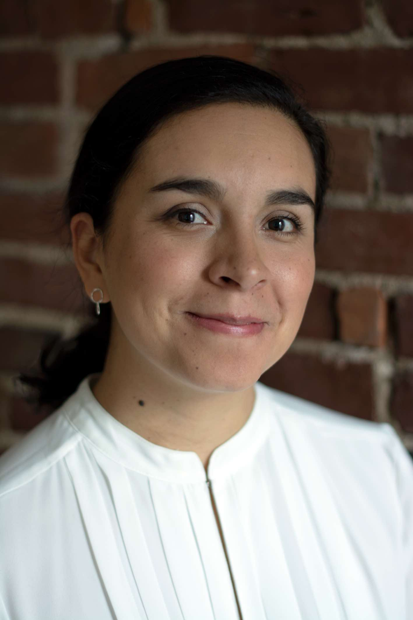

## Yina Quique, Ph.D

I am a clinician-scientist committed to improving rehabilitation outcomes and healthcare services for stroke survivors with aphasia. I am especially interested in developing culturally-sensitive and language-specific interventions for Spanish speakers with aphasia.

Outside of my work life, I enjoy coffee dates with my husband. I also love spending time with my niece and nephew.

[Github](https://github.com/yina-quique) Email [ORCID](https://orcid.org/0000-0001-9129-4742)

### My research path

I was trained as a Speech-Language Pathologist in Colombia, where I practiced for more than seven years. During that time, it gradually became evident that aphasia assessments and treatments were not designed for Spanish-speaking individuals and that a direct translation from English resources did not fully meet the needs of my patients. Moreover, over 85% of published aphasia treatment research has focused on English, leaving a need to advance aphasia research and evidence-based service delivery in other languages and cultures. To address this disparity, my research program has focused on:

1. developing culturally- and linguistically-specific aphasia interventions.
2. improving the efficacy and accessibility of aphasia treatments.

I completed my doctoral studies in Communication Science and Disorders at the [University of Pittsburgh](https://language-brain-lab.squarespace.com/alumni) with an [emphasis on aphasia rehabilitation](https://www.lrcl.pitt.edu/people/yina-quique-phd). I also worked as a postdoctoral fellow at Northwestern University and the [Shirley Ryan Ability lab](https://www.sralab.org/researchers/yina-m-quique-phd), strengthening my aphasia rehabilitation training and combining it with practical training in healthcare services and outcomes research.

I then expanded my work to global health. As a [Fogarty Global Health Fellow](https://hsph.harvard.edu/research/nutrition-and-global-health/hbnu-fogarty-global-health-training-program/), I worked on identifying barriers and facilitators of best-practice aphasia rehabilitation in Peru and Colombia. This experience allowed me to foster international collaborations between educational, research, and healthcare institutions.

In January 2025, I joined the Department of [Speech and Hearing Sciences](https://shs.unm.edu/) at the University of New Mexico (UNM). I am grateful for the opportunity to be a Latina in a Hispanic-serving institution in a minority-majority state. At UNM, I continue developing culturally- and linguistically-specific interventions for minorities with aphasia and improving the efficacy and accessibility of aphasia treatments.